# Importance sampling

On this report we denote $D$ as the observed-part or extant-species, $+_i$ as the missing-part or extinct-species of the tree and $D^+$ is then the complete phylogenetic tree.

The EM algorithms consists on two steps. First, we calculate the conditional expectation:

$$Q(\theta|\theta^*) = E_{\theta^* } [log P(D^+|\theta) | D]$$

and then we perform the maximization:

$$\theta ^{**} = argmax_{(\theta)} Q( \theta | \theta ^*)$$

Given that the calculation of the conditional expectation is really hard (if not impossible), we use an approximation, sampling complete-phylogenies under a montecarlo approach. This simulations should be sampled from (real density)

$$f_{\theta^*} (+_i | D)$$

But instead we sample it from

$$g_{\theta^*}(+_i | D)$$

To correct this we re-weigh the approximation of the expectation by importance scaling:

$$w_i = \frac{f_{\theta^*} (+_i | D)}{g_{\theta^*}(+_i | D)} = \frac{f_i}{g_i}$$

Thus, the montecarlo re-weighted approximation has the form

$$E_{\theta^* } [log P(D^+|\theta) | D] \approx \frac{1}{N} \sum^{N}_{i=1} log P(D_i^+ | \theta) \frac{f_i}{g_i}$$

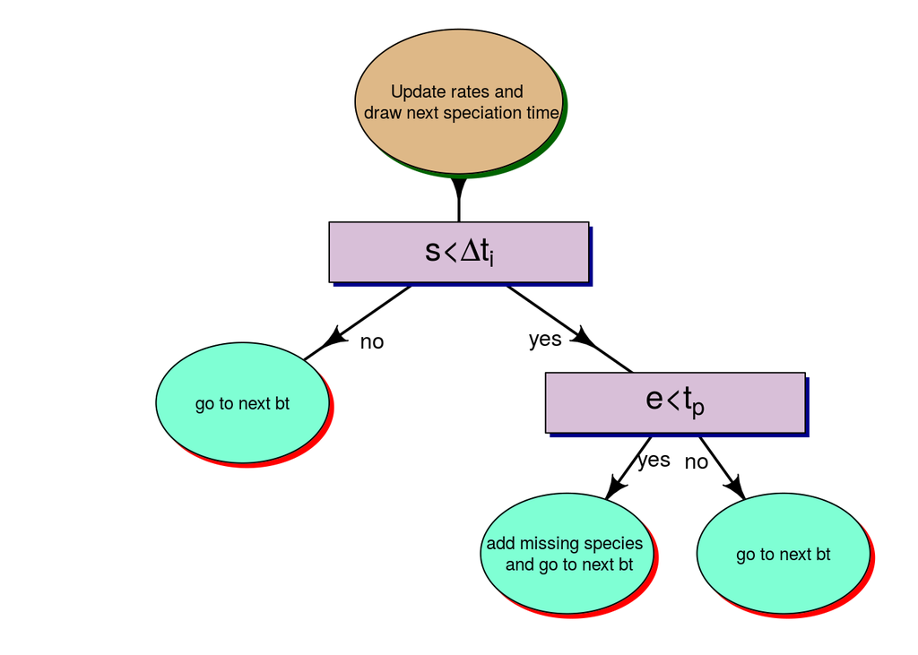

we multiply the corresponding probabilities to have every outcome, this is done on the piece of code bellow

```r
  if (t_spe < cwt){
      t_ext = rexp(1,mu0)
      t_ext = cbt + t_spe + t_ext
      if (t_ext < ct){
        up = update_tree(wt=wt,t_spe = (cbt + t_spe), t_ext = t_ext, E = E, n = n)
        E = up$E
        n = up$n
        wt = up$wt
        fake = FALSE
        prob[i] = dexp(t_ext,rate=mu0,log=TRUE) + dexp(t_spe,rate=s,log = TRUE)
      }else{
        prob[i] = pexp(q = ct,rate = mu0,lower.tail = F,log.p = TRUE) + dexp(t_spe,rate=s, log = TRUE)
        fake = TRUE
        i = i-1
      }
    }else{
      fake = FALSE
      prob[i] = pexp(q = cwt,rate = s,lower.tail = F,log.p = TRUE)
    }
```

Note that we are working with multiplication of many densities, which in the end are very small values. To avoid cutting most numbers to zero we consider the following fact:

$$w_i = \frac{f_i}{g_i} = e^{log(f_i) - log(g_i)} = e^{loglik - \sum_j log(g_{i,j})}$$

and that is why on the code above the log of the densities is calculated. Considering that we calculate the weight in the following way

```r
f_n = -llik(b=pars,n=n,E=E,t=wt)
logweight = f_n-sum(prob)
return(list(wt=wt,E=E,n=n,weight=logweight,L=L,g=prob,f_n=f_n))
```

another way to calculate $g$ is considering the probabilities of not having a new species on the interval $\Delta t_i$

$$\int_0^{\Delta t_i} s_{\lambda_i}e^{-s_{\lambda_i} t}[1-e^{-\mu (r_i-t)}] dt = s_{\lambda_i}\int_0^{\Delta t_i}e^{-s_{\lambda_i} t}-e^{ t(\mu-s_{\lambda_i})-\mu r_i} = s_{\lambda_i}\int_0^{\Delta t_i}e^{-s_{\lambda_i} t}dt - s_{\lambda_i} e^{-\mu r_i} \int_0^{\Delta t_i}e^{ t(\mu-s_{\lambda_i})} dt$$
$$= 1-e^{-s_{\lambda_i} \Delta t} -\frac{s_{\lambda_i} e^{-\mu r_i}}{\mu - s_{\lambda_i}}[e^{\Delta t(\mu-s_{\lambda_i})}-1]$$
so we do it with this function

```r
convol <-function(wt,lambda,mu,remt){
  out = 1-exp(-lambda*wt)-lambda*exp(-mu*remt)/(mu-lambda)*(exp(wt*(mu-lambda))-1)
  return(out)
}
```

and we add this option to the code

```r
 if (t_spe < cwt){
      t_ext = rexp(1,mu0)
      t_ext = cbt + t_spe + t_ext
      if (t_ext < ct){
        up = update_tree(wt=wt,t_spe = (cbt + t_spe), t_ext = t_ext, E = E, n = n)
        E = up$E
        n = up$n
        wt = up$wt
        fake = FALSE
        prob[i] = dexp(t_ext,rate=mu0,log=TRUE) + dexp(t_spe,rate=s,log = TRUE)
      }else{
        prob[i] = pexp(q = ct,rate = mu0,lower.tail = F,log.p = TRUE) + dexp(t_spe,rate=s,log = TRUE)
        if(v2){ prob[i] = log(convol(wt = t_spe,lambda = s,mu = mu,remt = ct-cbt))}
        fake = TRUE
        i = i-1
      }
    }else{
      fake = FALSE
      prob[i] = pexp(q = cwt,rate = s,lower.tail = F,log.p = TRUE)
      if(v2){prob[i] = log(convol(wt = t_spe,lambda = s,mu = mu,remt = ct-cbt))}
    }
```

### Implementation

To have a better idea on how this implementation look like we do some simple observations.

We start simulating a whole tree

```r
s <- sim_phyl()
```

Them we drop extinct species

```r
s2 <- drop.fossil(s$newick)
```

we transform phylo format into branching-times, number of species, and topology vectors

```r
s2 <- phylo2p(s2)
```

Now we simulate a complete tree (extinct+extans species) based on the observed tree (extant species only)

```r
s3 <- rec_tree(wt=s2$wt)
```

and we observe the calculated weight for this tree

```r
s3$weight
```

```
## [1] -217.4005
```

it seems very small

```r
l = proc.time()
w=0
nLTT=0
n_it = 10000
st=sim_srt(wt=s2$wt,pars=c(0.8,0.0175,0.1),n_trees = n_it,parallel = TRUE)
for(i in 1:n_it){
  st3 = st[[i]]
  w[i] = st3$weight
  rec = p2phylo(st3)
  nLTT[i] = ltt_stat(s$newick, rec)
}
print(proc.time()-l)
```

```
##     user   system  elapsed
## 1970.316    0.264 2333.628
```

```r
su=summary(w)
su
```

```
##    Min. 1st Qu.  Median    Mean 3rd Qu.    Max.
##    -Inf  -221.0  -205.2    -Inf  -193.9  -153.3
```

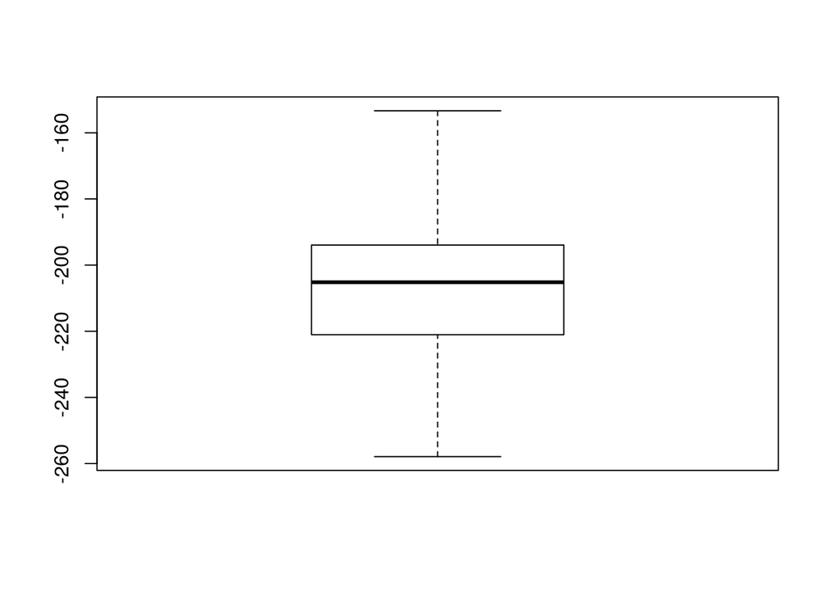

```r
boxplot(w)
```

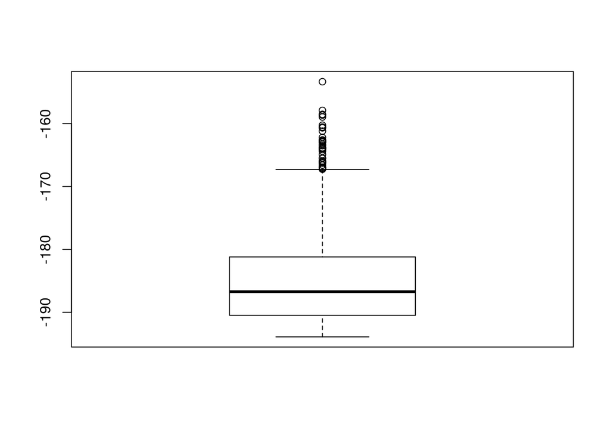

```r
q3 = w>su[5]
boxplot(w[q3])
```

They seems very small to be the logarithm of the weight, we centreate it to avoid numerical issues

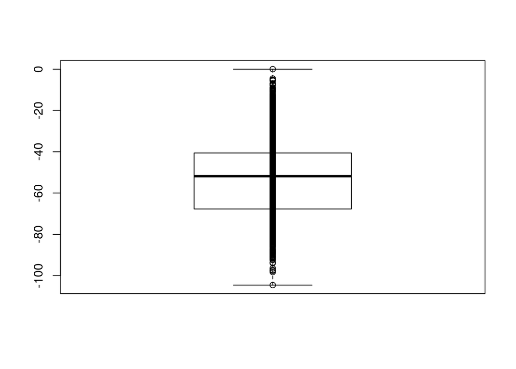

```r
w = w - max(w)
boxplot(w)
points(rep(1,length(w)),w)
```

now we would like to check if trees with larger weight are really ‘’better trees’’. To do that we check the nLTT statistic

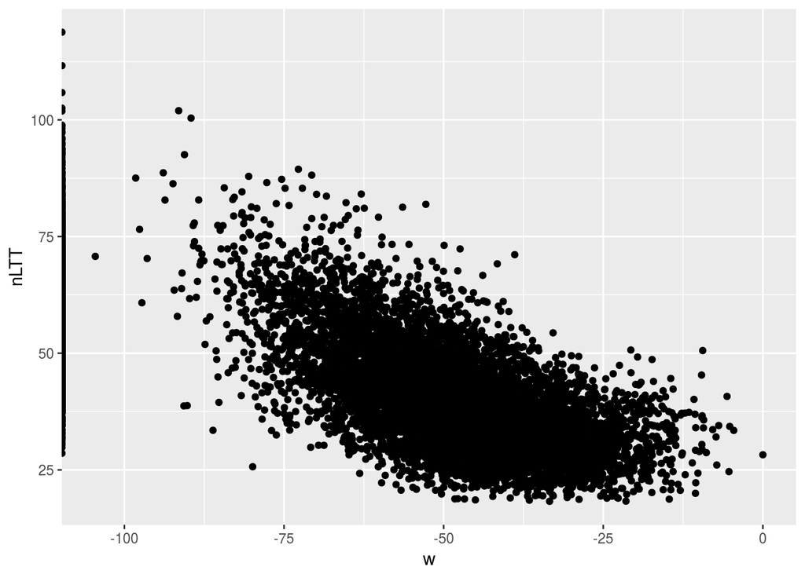

```r
qplot(w,nLTT)
```

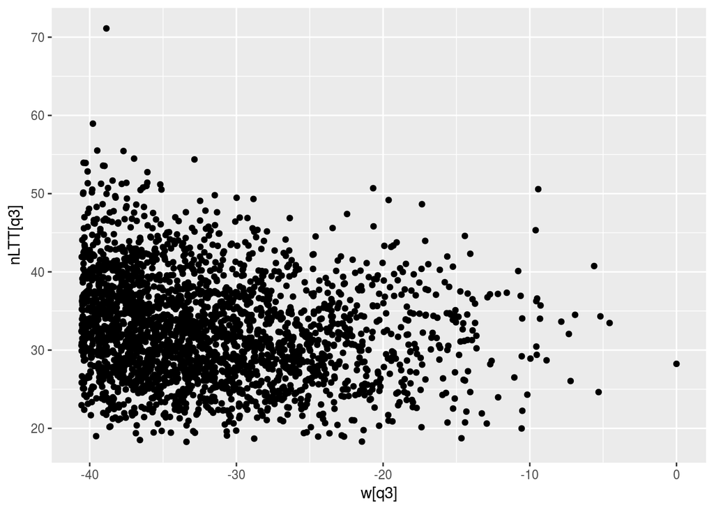

```r
qplot(w[q3],nLTT[q3])
```

Now let´s check the real weights, that is

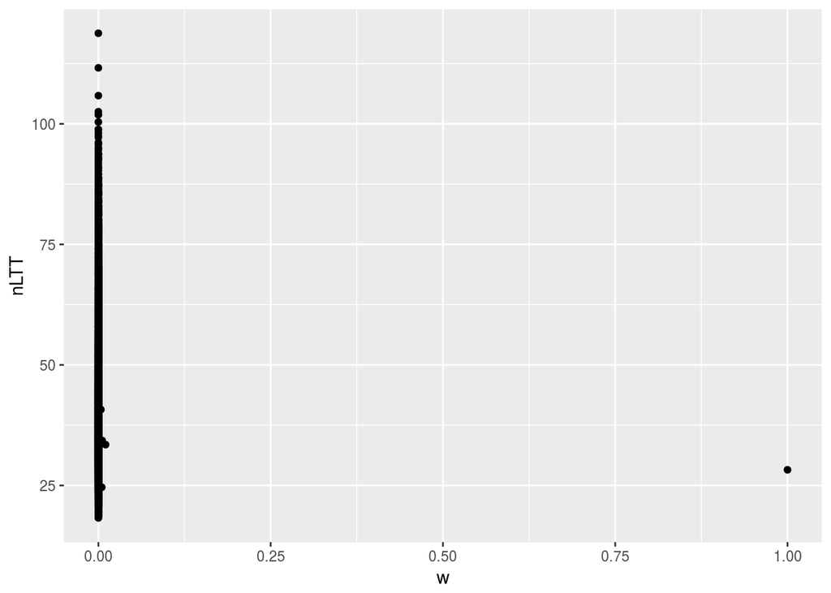

```r
w = exp(w)
qplot(w,nLTT)
```

```r
phyl = st[[which(w==1)]]
pars = c(1.6,0.02,0.5)
subplex(par = pars, fn = llik_st, setoftrees = list(phyl), impsam = F)$par
```

```
## [1] 0.79206147 0.01906023 0.05218190
```

```r
subplex(par = pars, fn = llik_st, setoftrees = st, impsam = F)$par
```

```
## [1] 0.59524794 0.01167148 0.06941716
```

```r
subplex(par = pars, fn = llik_st, setoftrees = st, impsam = T)$par
```

```
## [1] 0.59612234 0.01324716 0.05219995
```

```r
subplex(par = pars, fn = llik_st, setoftrees = list(s), impsam = F)$par
```

```
## [1] 0.99847149 0.02235446 0.10875145
```

now the same but with the second way

```r
s3 <- rec_tree(wt=s2$wt,v2=T)
```

and we observe the calculated weight for this tree

```r
s3$weight
```

```
## [1] -Inf
```

it seems very small

```r
w=0
for(i in 1:100){
st3 <- rec_tree(wt=s2$wt,v2=T)
w[i] = st3$weight
}
print(w)
```

```
##   [1]    0.00000 -120.03740 -185.00721    0.00000 -168.50230 -190.10843
##   [7]    0.00000    0.00000 -180.43485 -113.18749    0.00000 -107.16458
##  [13] -136.80997 -134.71493       -Inf       -Inf -105.71592 -123.88677
##  [19] -113.64027 -129.61582       -Inf -160.63713    0.00000 -128.98988
##  [25] -110.14218 -122.00697 -196.92250 -117.23903    0.00000       -Inf
##  [31] -117.04748 -111.04143 -134.09884 -205.63515    0.00000 -142.01180
##  [37]       -Inf -114.05368 -145.04136 -187.03340 -107.02115 -182.73301
##  [43] -103.30793  -90.98218    0.00000 -136.65036 -200.48037 -127.75454
##  [49] -113.22482 -110.76000    0.00000       -Inf    0.00000    0.00000
##  [55] -113.09960 -136.80950 -114.22815 -177.28258    0.00000  -96.62338
##  [61] -120.18138       -Inf -225.07568    0.00000       -Inf    0.00000
##  [67] -114.25306    0.00000 -130.36966    0.00000 -191.30743       -Inf
##  [73] -131.66507       -Inf    0.00000    0.00000 -121.06627 -106.72801
##  [79] -187.07270 -115.54333 -121.03488       -Inf       -Inf -131.37039
##  [85] -207.83785       -Inf       -Inf -123.44558 -170.76459    0.00000
##  [91]       -Inf -123.36522 -111.16022 -182.31718 -189.04244    0.00000
##  [97] -103.09732 -117.00939 -105.84009    0.00000
```

```r
w = w - max(w)
print(w)
```

```
##   [1]    0.00000 -120.03740 -185.00721    0.00000 -168.50230 -190.10843
##   [7]    0.00000    0.00000 -180.43485 -113.18749    0.00000 -107.16458
##  [13] -136.80997 -134.71493       -Inf       -Inf -105.71592 -123.88677
##  [19] -113.64027 -129.61582       -Inf -160.63713    0.00000 -128.98988
##  [25] -110.14218 -122.00697 -196.92250 -117.23903    0.00000       -Inf
##  [31] -117.04748 -111.04143 -134.09884 -205.63515    0.00000 -142.01180
##  [37]       -Inf -114.05368 -145.04136 -187.03340 -107.02115 -182.73301
##  [43] -103.30793  -90.98218    0.00000 -136.65036 -200.48037 -127.75454
##  [49] -113.22482 -110.76000    0.00000       -Inf    0.00000    0.00000
##  [55] -113.09960 -136.80950 -114.22815 -177.28258    0.00000  -96.62338
##  [61] -120.18138       -Inf -225.07568    0.00000       -Inf    0.00000
##  [67] -114.25306    0.00000 -130.36966    0.00000 -191.30743       -Inf
##  [73] -131.66507       -Inf    0.00000    0.00000 -121.06627 -106.72801
##  [79] -187.07270 -115.54333 -121.03488       -Inf       -Inf -131.37039
##  [85] -207.83785       -Inf       -Inf -123.44558 -170.76459    0.00000
##  [91]       -Inf -123.36522 -111.16022 -182.31718 -189.04244    0.00000
##  [97] -103.09732 -117.00939 -105.84009    0.00000
```

```r
w = exp(w)
print(w)
```

```
##   [1] 1.000000e+00 7.386186e-53 4.491490e-81 1.000000e+00 6.612706e-74
##   [6] 2.735015e-83 1.000000e+00 1.000000e+00 4.346527e-79 6.971071e-50
##  [11] 1.000000e+00 2.877494e-47 3.838712e-60 3.119233e-59 0.000000e+00
##  [16] 0.000000e+00 1.225061e-46 1.572753e-54 4.432579e-50 5.111698e-57
##  [21] 0.000000e+00 1.722581e-70 1.000000e+00 9.558924e-57 1.465068e-48
##  [26] 1.030497e-53 3.003616e-86 1.212649e-51 1.000000e+00 0.000000e+00
##  [31] 1.468672e-51 5.960994e-49 5.775818e-59 4.940696e-90 1.000000e+00
##  [36] 2.113782e-62 0.000000e+00 2.931690e-50 1.021735e-63 5.921423e-82
##  [41] 3.321274e-47 4.365795e-80 1.361243e-45 3.068621e-40 1.000000e+00
##  [46] 4.502999e-60 8.560137e-88 3.287812e-56 6.715625e-50 7.898453e-49
##  [51] 1.000000e+00 0.000000e+00 1.000000e+00 1.000000e+00 7.611484e-50
##  [56] 3.840507e-60 2.462313e-50 1.016612e-77 1.000000e+00 1.088926e-42
##  [61] 6.395738e-53 0.000000e+00 1.781858e-98 1.000000e+00 0.000000e+00
##  [66] 1.000000e+00 2.401733e-50 1.000000e+00 2.405338e-57 1.000000e+00
##  [71] 8.245944e-84 0.000000e+00 6.585450e-58 0.000000e+00 1.000000e+00
##  [76] 1.000000e+00 2.639898e-53 4.452590e-47 5.693204e-82 6.609502e-51
##  [81] 2.724067e-53 0.000000e+00 0.000000e+00 8.842313e-58 5.459688e-91
##  [86] 0.000000e+00 0.000000e+00 2.444932e-54 6.884601e-75 1.000000e+00
##  [91] 0.000000e+00 2.649517e-54 5.293344e-49 6.616870e-80 7.941692e-83
##  [96] 1.000000e+00 1.680354e-45 1.525688e-51 1.082016e-46 1.000000e+00
```

So, a first observation, the values of w are really small and varies a lot. That is amaking a lot of numerical inestabilities.

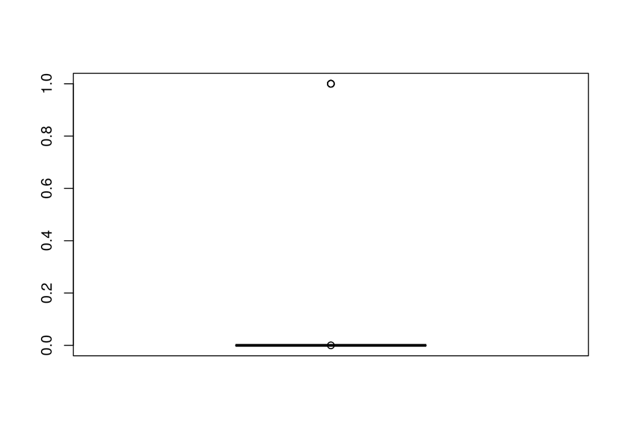

```r
boxplot(w)
```

```r
summary(w)
```

```
##    Min. 1st Qu.  Median    Mean 3rd Qu.    Max.
##    0.00    0.00    0.00    0.22    0.00    1.00
```

we can also see how few trees has almost the whole weight and defines the outcome